# Final Project

Philip McCormick

5/15/2022

**Literature Review**

The issue of rising sea levels and water scarcity that are plaguing growing communities are ones that must be addressed in the coming decades, and just how to combat them will be an issue of contention. An interesting technology that some countries believe can solve both problems are desalination facilities. These plants take sea water and detoxify it for human use and consumption. Moving forward, the question of how efficient they actually are is vital. The first paper I looked at to answer the question of efficacy focused on Israel, and aimed to ask about the effectiveness of water desalination plants there (Becker, 2011). It first asks, what are direct and indirect external costs of desalination plants for the country. Since there are many ways to address water scarcity, they wanted to understand what the overall impacts of these facilities comes to be. Second, they tackle whether or not other alternatives to water mitigation might not be more viable. They look at three alternatives, increasing wastewater capture and reuse, promotion of water saving technology, and water reduction for agricultural endeavors. The empirical approaches taken are that external costs of desalination plants along coastlines in Israel can be expressed with an equation of C = ( AV*DP)/Q. In this equation, the dependent variable, C is cost per cubic meter of water the plant produces. The independent variables are represented by AV, for average monetary value of Israeli coastline property per unit area, DP, the coastline area taken by desalination plants, and Q, the quantity of desalinated water in cubic meters. The researchers also used a semi-logarithmic function, P =16.11– 2.394 ln(W), to express demand for water in Israel, where P is the price of water, and W is the amount of water used in million cubic meters (MCM).  
A challenge faced by the researcher was coming up with costs of negative externalities to habitats surrounding areas of these facilities. Desalination plants suck in massive amounts of water and in doing so bring in marine life as well as alter their habitits. Since it is difficult to account for damage to the natural habitats, they were unable to estimate the full effects. The ultimate findings were that desalination plants were too cost ineffective to be viable. They suggested Israel postpone further development of these plants along their coastline and instead shift to water saving and wastewater treatment alternatives which have fewer negative externalities and are less expensive. They believe desalination plants should be reassessed at a future date (ten years in the future they suggest) when technology may be more efficient and safer for the production level Israel is looking for from them. The second research paper (Al Ashry, 2015), looks at the three main types of desalination plants and does a cost-benefit analysis of each type. It aims to understand the economic efficiency of nuclear, gas, and solar desalination plants, and ultimately pick the strongest option. In exploring different energy sources for desalination plants, the researcher uses a number of equations to understand the cost-benefit of each type of plant. They use a first-order autoregressive model to estimate revenues from each of three types of plants, an equation to test the stability and deviation of the explained and unexplained variation in the autoregressive model between actual and estimated variance, then they use a variance ratio to test for the random walk hypothesis, and finally, they employ a heteroscedasticity asymptotic variance to test for consistency.  
The author came across challenges incorporating solar radiation in different nations. This may have affected the accuracy of their calculations on impacts of solar power desalination plants in different hemispheres with varying amounts of sunlight. The paper comes to a similar conclusion as the first. Although it appeals to people’s futuristic mindsets, at the moment desalination plants are not as beneficial as we would like them to be. They find that of the three options gas, nuclear, or solar plants, solar seems to be the best due to ease of construction and maintenance.  
This literature has changed my view of the question I initially asked, as to whether desalination plants are a worthwhile investment to address rising sea levels, in that it appears the academic community is in agreement that, at the moment, they are not. The current cost, externalities, and capacity of these facilities seem to out way their benefit to communities they aim to serve. Moving forward I believe I will alter my question to what financial alterations would have to happen to make solar powered desalination plants a viable option for coastal regions. To collect data for my altered topic of research I will need to focus my research on solar powered desalination plants. I will aim to collect their cost, maintenance, and output, as well as estimated externalities to local areas to better understand what their impacts are, and what is needed to offset these.

Reference:

1. Al Ashry, Mohammed. “Large Scale Desalination: A Comparative Cost Affective Economic Analyses of Nuclear, Gas and Solar Powered Plants.” Theoretical Economics Letters, vol. 01, no. 05, 2015, pp. 103–113, 10.4236/tel.2015.51015.
2. Becker, Nir. “Is Desalination the Most Sustainable Alternative for Water-Shortage Mitigation in Israel?” International Journal of Sustainable Economy, vol. 3, no. 4, Jan. 2011, pp. 410–424, 10.1504/IJSE.2011.042796.

**Data Choice**

I had difficulty finding a data set with useful data on the topic of desalination plants and their benefits to regions they are operating in. Due to the construction costs and efficiency of these sites, those companies that install them do not like to give out information so the closest I could find to data on these sites was location based, and only gave categorical and qualitative data.

Since we can not run regression on categorical variables I will be relying on the data set related to vicinity to an incinerator plant, “kielmc” to run theoretical regressions and tests. Upon analysis of the data only minor cleaning and processing needs to be done prior to testing. This will serve as way to analyze how price of homes flucuate in response to variables, some of which relate to vicinity towards processing plants.

**Data Import and Analysis**

```r
df <- read.csv('kielmc.csv', stringsAsFactors = FALSE)

#get a quanitative idea of values in th data
summary(df)
```

```
##       year           age             agesq            nbh
##  Min.   :1978   Min.   :  0.00   Min.   :    0   Min.   :0.000
##  1st Qu.:1978   1st Qu.:  0.00   1st Qu.:    0   1st Qu.:0.000
##  Median :1978   Median :  4.00   Median :   16   Median :2.000
##  Mean   :1979   Mean   : 18.01   Mean   : 1382   Mean   :2.209
##  3rd Qu.:1981   3rd Qu.: 22.00   3rd Qu.:  484   3rd Qu.:4.000
##  Max.   :1981   Max.   :189.00   Max.   :35721   Max.   :6.000
##       cbd            intst           lintst           price
##  Min.   : 1000   Min.   : 1000   Min.   : 6.908   Min.   : 26000
##  1st Qu.: 9000   1st Qu.: 9000   1st Qu.: 9.105   1st Qu.: 65000
##  Median :14000   Median :16000   Median : 9.680   Median : 85900
##  Mean   :15822   Mean   :16442   Mean   : 9.481   Mean   : 96101
##  3rd Qu.:23000   3rd Qu.:24000   3rd Qu.:10.086   3rd Qu.:120000
##  Max.   :35000   Max.   :34000   Max.   :10.434   Max.   :300000
##      rooms             area           land            baths
##  Min.   : 4.000   Min.   : 735   Min.   :  1710   Min.   :1.00
##  1st Qu.: 6.000   1st Qu.:1560   1st Qu.: 16935   1st Qu.:2.00
##  Median : 7.000   Median :2056   Median : 43560   Median :2.00
##  Mean   : 6.586   Mean   :2107   Mean   : 39630   Mean   :2.34
##  3rd Qu.: 7.000   3rd Qu.:2544   3rd Qu.: 46100   3rd Qu.:3.00
##  Max.   :10.000   Max.   :5136   Max.   :544500   Max.   :4.00
##       dist           ldist             wind            lprice
##  Min.   : 5000   Min.   : 8.517   Min.   : 3.000   Min.   :10.17
##  1st Qu.:13400   1st Qu.: 9.503   1st Qu.: 5.000   1st Qu.:11.08
##  Median :19900   Median : 9.898   Median : 7.000   Median :11.36
##  Mean   :20716   Mean   : 9.837   Mean   : 6.978   Mean   :11.38
##  3rd Qu.:27200   3rd Qu.:10.211   3rd Qu.:11.000   3rd Qu.:11.70
##  Max.   :40000   Max.   :10.597   Max.   :11.000   Max.   :12.61
##      wind.1          lprice.1          y81             larea
##  Min.   :0.0000   Min.   :6.600   Min.   : 7.444   Min.   : 0.0000
##  1st Qu.:0.0000   1st Qu.:7.352   1st Qu.: 9.737   1st Qu.: 0.0000
##  Median :0.0000   Median :7.629   Median :10.682   Median : 0.0000
##  Mean   :0.4424   Mean   :7.597   Mean   :10.302   Mean   : 0.7102
##  3rd Qu.:1.0000   3rd Qu.:7.841   3rd Qu.:10.739   3rd Qu.: 0.4174
##  Max.   :1.0000   Max.   :8.544   Max.   :13.208   Max.   :10.4631
##      lland           y81ldist         lintstsq         nearinc
##  Min.   : 47.72   Min.   :0.0000   Min.   :0.0000   Min.   : 26000
##  1st Qu.: 82.90   1st Qu.:0.0000   1st Qu.:0.0000   1st Qu.: 59000
##  Median : 93.71   Median :0.0000   Median :0.0000   Median : 82000
##  Mean   : 90.48   Mean   :0.2991   Mean   :0.1246   Mean   : 83721
##  3rd Qu.:101.73   3rd Qu.:1.0000   3rd Qu.:0.0000   3rd Qu.:100230
##  Max.   :108.87   Max.   :1.0000   Max.   :1.0000   Max.   :300000
##     y81nrinc
##  Min.   :10.17
##  1st Qu.:10.99
##  Median :11.31
##  Mean   :11.26
##  3rd Qu.:11.52
##  Max.   :12.61
```

```r
#understand dimensions and data
dim(df)
```

```
## [1] 321  25
```

```r
str(df)
```

```
## 'data.frame':    321 obs. of  25 variables:
##  $ year    : int  1978 1978 1978 1978 1978 1978 1978 1978 1978 1978 ...
##  $ age     : int  48 83 58 11 48 78 22 78 42 41 ...
##  $ agesq   : int  2304 6889 3364 121 2304 6084 484 6084 1764 1681 ...
##  $ nbh     : int  4 4 4 4 4 4 4 4 4 4 ...
##  $ cbd     : int  3000 4000 4000 4000 4000 3000 4000 3000 3000 3000 ...
##  $ intst   : int  1000 1000 1000 1000 2000 2000 2000 2000 2000 2000 ...
##  $ lintst  : num  6.91 6.91 6.91 6.91 7.6 ...
##  $ price   : int  60000 40000 34000 63900 44000 46000 56000 38500 60500 55000 ...
##  $ rooms   : int  7 6 6 5 5 6 6 6 8 5 ...
##  $ area    : int  1660 2612 1144 1136 1868 1780 1700 1556 1642 1443 ...
##  $ land    : int  4578 8370 5000 10000 10000 9500 10878 3870 7000 7950 ...
##  $ baths   : int  1 2 1 1 1 3 2 2 2 2 ...
##  $ dist    : int  10700 11000 11500 11900 12100 10000 11700 10200 10500 11000 ...
##  $ ldist   : num  9.28 9.31 9.35 9.38 9.4 ...
##  $ wind    : int  3 3 3 3 3 3 3 3 3 3 ...
##  $ lprice  : num  11 10.6 10.4 11.1 10.7 ...
##  $ wind.1  : int  0 0 0 0 0 0 0 0 0 0 ...
##  $ lprice.1: num  7.41 7.87 7.04 7.04 7.53 ...
##  $ y81     : num  8.43 9.03 8.52 9.21 9.21 ...
##  $ larea   : num  0 0 0 0 0 0 0 0 0 0 ...
##  $ lland   : num  47.7 47.7 47.7 47.7 57.8 ...
##  $ y81ldist: int  1 1 1 1 1 1 1 1 1 1 ...
##  $ lintstsq: int  0 0 0 0 0 0 0 0 0 0 ...
##  $ nearinc : num  60000 40000 34000 63900 44000 46000 56000 38500 60500 55000 ...
##  $ y81nrinc: num  11 10.6 10.4 11.1 10.7 ...
```

```r
colnames(df)
```

```
##  [1] "year"     "age"      "agesq"    "nbh"      "cbd"      "intst"
##  [7] "lintst"   "price"    "rooms"    "area"     "land"     "baths"
## [13] "dist"     "ldist"    "wind"     "lprice"   "wind.1"   "lprice.1"
## [19] "y81"      "larea"    "lland"    "y81ldist" "lintstsq" "nearinc"
## [25] "y81nrinc"
```

```r
#look for missing values
table(is.na(df))
```

```
##
## FALSE
##  8025
```

```r
#looking at potential dependent variable
max(df$price)
```

```
## [1] 300000
```

```r
min(df$price)
```

```
## [1] 26000
```

```r
mean(df$price)
```

```
## [1] 96100.66
```

```r
#looking at potential independent variables
max(df$dist)
```

```
## [1] 40000
```

```r
min(df$dist)
```

```
## [1] 5000
```

```r
mean(df$dist)
```

```
## [1] 20715.58
```

```r
max(df$rooms)
```

```
## [1] 10
```

```r
min(df$rooms)
```

```
## [1] 4
```

```r
mean(df$rooms)
```

```
## [1] 6.58567
```

The data has a 321 observations across 25 different variables. There are no missing values in the data set. Upon the initial look into the data, we see a large assortment of quantitative variables to choose from, including some dummy variables that can be used in our regressions. Looking at the summary statistics can help understand the quantitative aspects of our data.

**Graphs and Distributions**

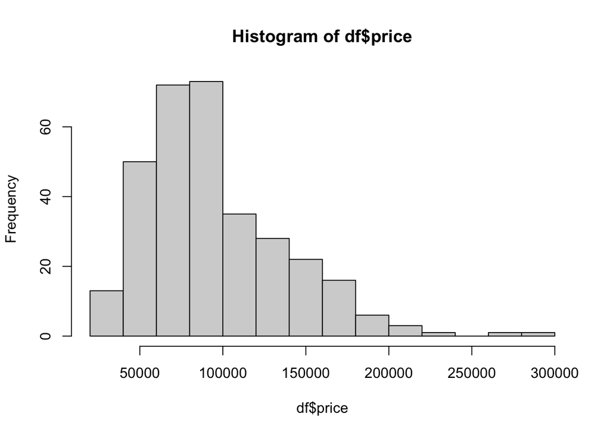

```r
hist(df$price)
```

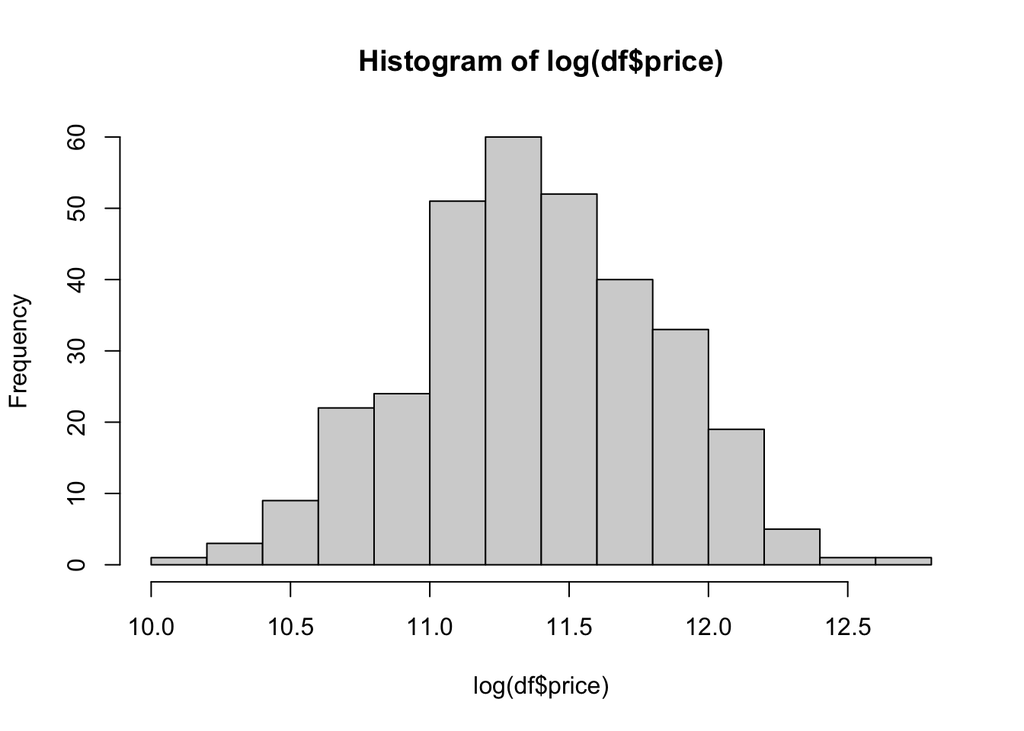

```r
#skewed right, log fixes skew to normal distr
hist(log(df$price))
```

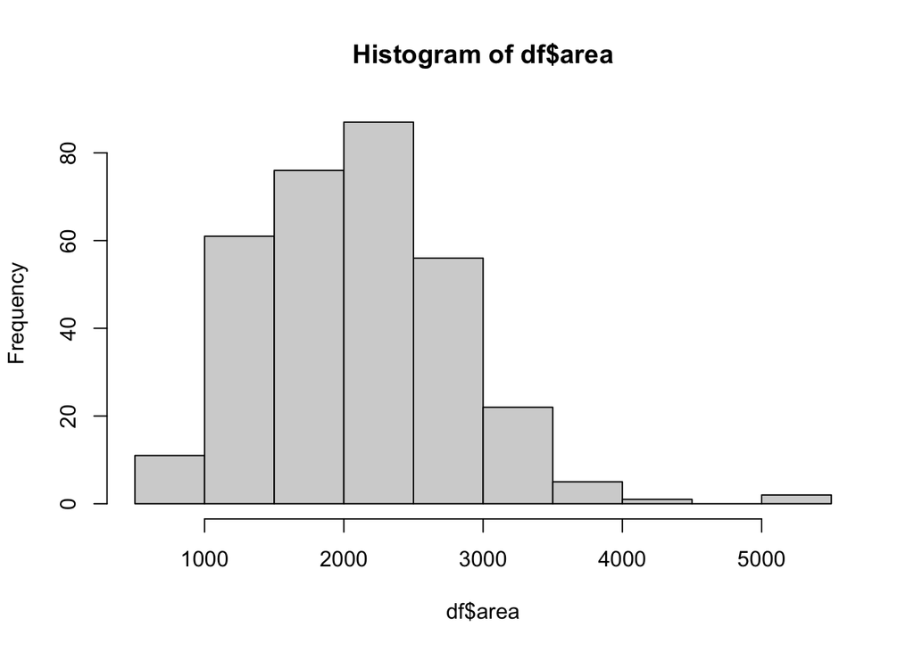

```r
#fairly normal distr
hist(df$area)
```

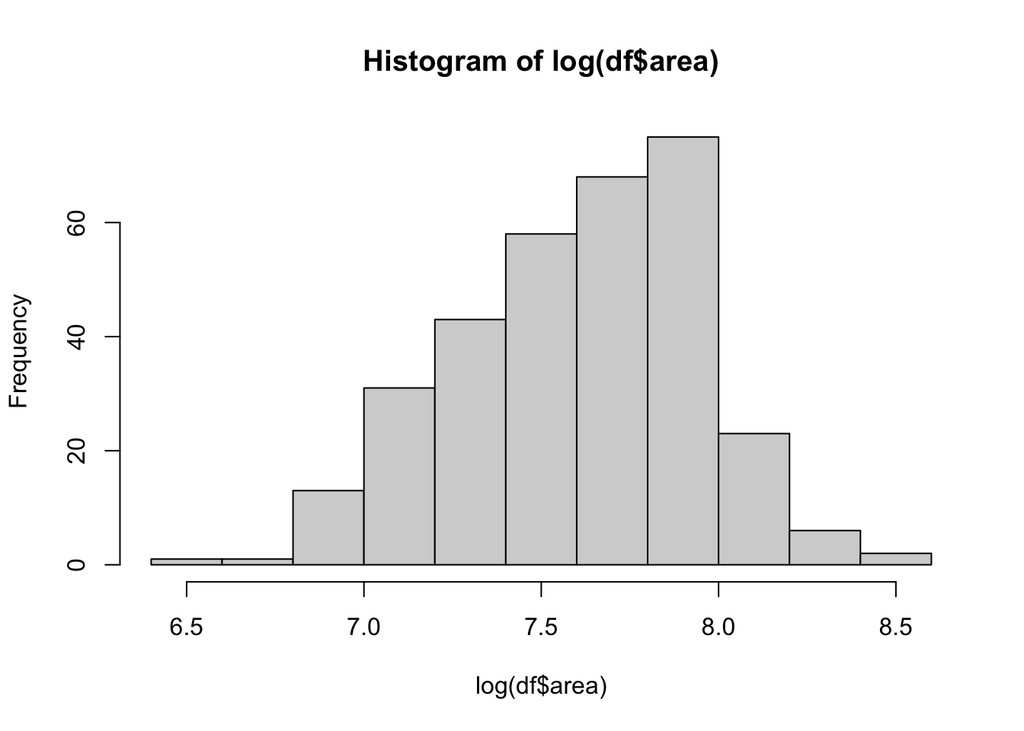

```r
#log doesn't fix much
hist(log(df$area))
```

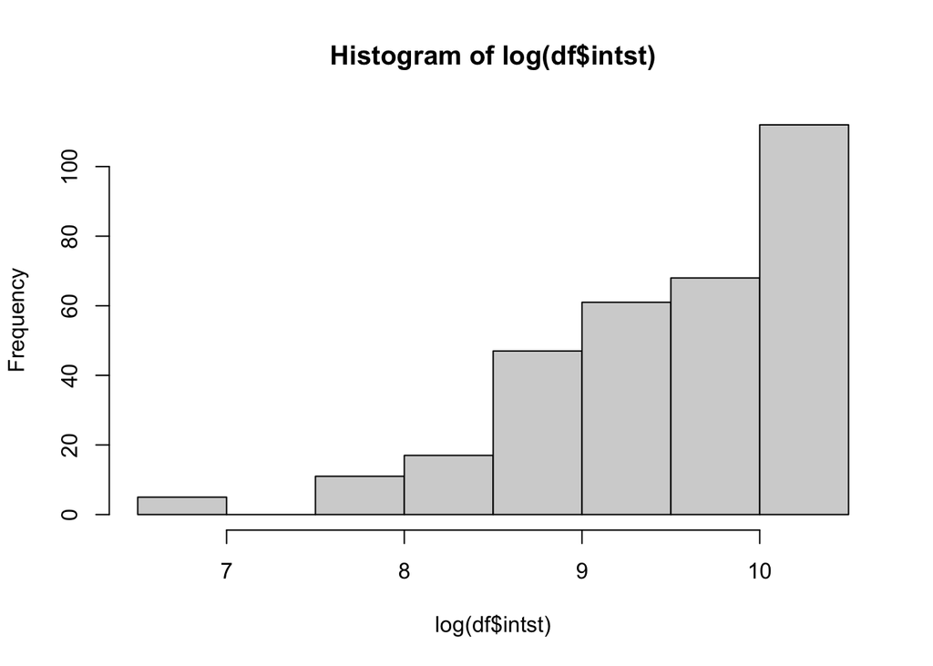

```r
#use log on large scaling data to fix distr
hist(log(df$intst))
```

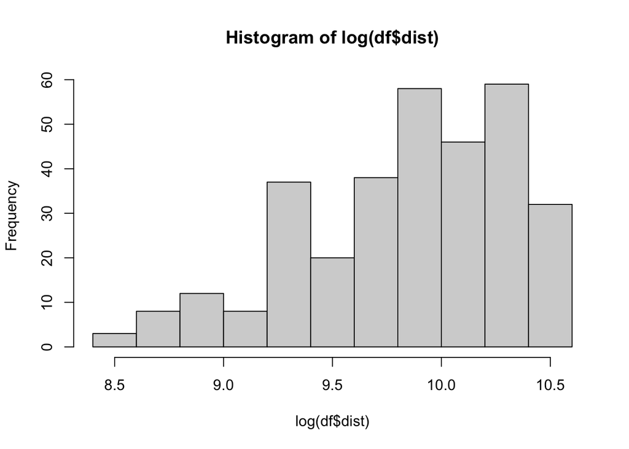

```r
hist(log(df$dist))
```

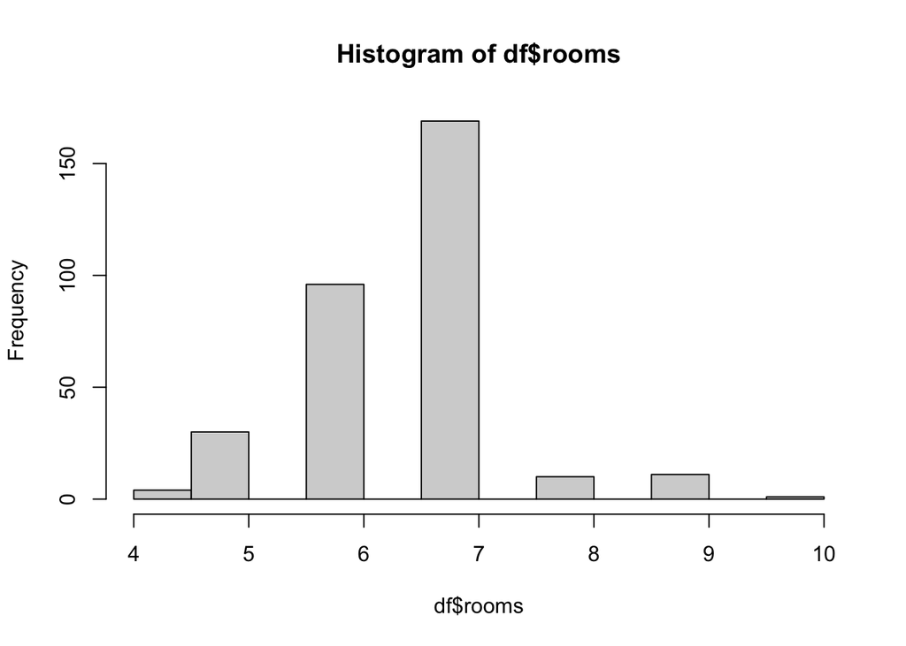

```r
hist(df$rooms)
```

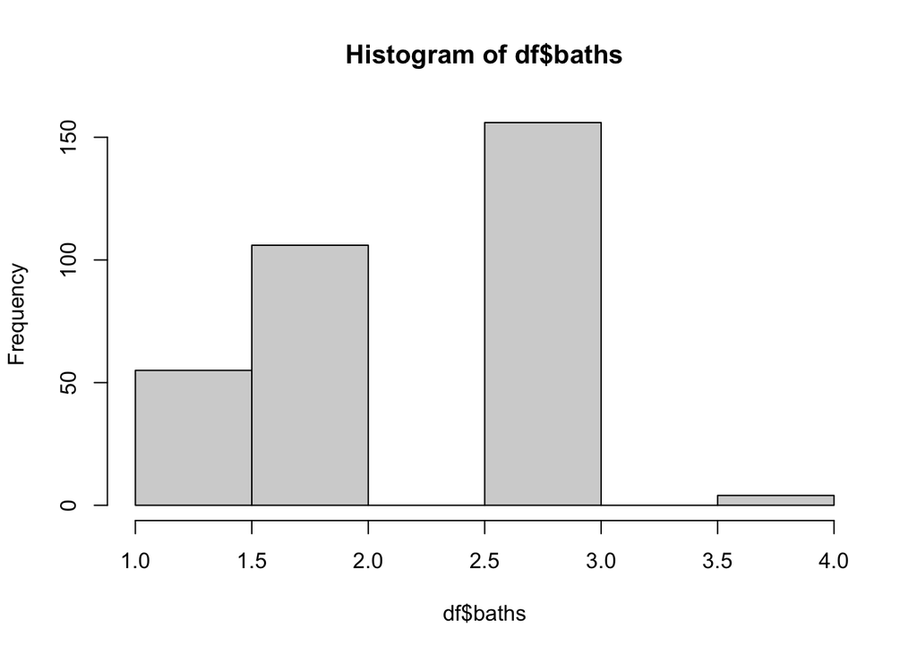

```r
hist(df$baths)
```

**Simple Regression Models** *log(price) = b<sub>0</sub> + b<sub>1</sub> + u* In this starting simple regression model, *log(price)* is the dependent variable, and is the log price that the house in the data set sold for. The following regressions will perform t-tests on selected variables at the 95% confidence interval that the variables are statistically signifcant and test the the null hypothesis, H<sub>0</sub>=B<sub>1</sub>=0, and the alternative hypothesis H<sub>0</sub>=B<sub>1</sub> not equal to 0.

```r
#1 Simple Regression
reg_1 <- lm(log(price) ~ dist, data=df)
summary(reg_1)
```

```
##
## Call:
## lm(formula = log(price) ~ dist, data = df)
##
## Residuals:
##      Min       1Q   Median       3Q      Max
## -1.19300 -0.31126 -0.05756  0.28315  1.30982
##
## Coefficients:
##              Estimate Std. Error t value Pr(>|t|)
## (Intercept) 1.107e+01  6.189e-02 178.931  < 2e-16 ***
## dist        1.465e-05  2.764e-06   5.299 2.18e-07 ***
## ---
## Signif. codes:  0 '***' 0.001 '**' 0.01 '*' 0.05 '.' 0.1 ' ' 1
##
## Residual standard error: 0.4207 on 319 degrees of freedom
## Multiple R-squared:  0.0809, Adjusted R-squared:  0.07802
## F-statistic: 28.08 on 1 and 319 DF,  p-value: 2.178e-07
```

```r
#2 Simple Regression
reg_2 <- lm(log(price) ~ rooms, data=df)
summary(reg_2)
```

```
##
## Call:
## lm(formula = log(price) ~ rooms, data = df)
##
## Residuals:
##      Min       1Q   Median       3Q      Max
## -1.31164 -0.22594 -0.02645  0.24482  1.13404
##
## Coefficients:
##             Estimate Std. Error t value Pr(>|t|)
## (Intercept)  9.79852    0.15739   62.25   <2e-16 ***
## rooms        0.23985    0.02368   10.13   <2e-16 ***
## ---
## Signif. codes:  0 '***' 0.001 '**' 0.01 '*' 0.05 '.' 0.1 ' ' 1
##
## Residual standard error: 0.3817 on 319 degrees of freedom
## Multiple R-squared:  0.2434, Adjusted R-squared:  0.241
## F-statistic: 102.6 on 1 and 319 DF,  p-value: < 2.2e-16
```

```r
#3 Simple Regression
reg_3 <- lm(log(price) ~ age, data=df)
summary(reg_3)
```

```
##
## Call:
## lm(formula = log(price) ~ age, data = df)
##
## Residuals:
##      Min       1Q   Median       3Q      Max
## -1.29871 -0.26489 -0.05146  0.26611  1.67328
##
## Coefficients:
##             Estimate Std. Error t value Pr(>|t|)
## (Intercept) 11.47536    0.02565 447.428  < 2e-16 ***
## age         -0.00540    0.00069  -7.825  7.5e-14 ***
## ---
## Signif. codes:  0 '***' 0.001 '**' 0.01 '*' 0.05 '.' 0.1 ' ' 1
##
## Residual standard error: 0.402 on 319 degrees of freedom
## Multiple R-squared:  0.1611, Adjusted R-squared:  0.1584
## F-statistic: 61.24 on 1 and 319 DF,  p-value: 7.504e-14
```

```r
#4 Simple Regression
reg_4 <- lm(log(price) ~ land, data=df)
summary(reg_4)
```

```
##
## Call:
## lm(formula = log(price) ~ land, data = df)
##
## Residuals:
##      Min       1Q   Median       3Q      Max
## -1.56607 -0.29857 -0.02718  0.32850  1.11906
##
## Coefficients:
##              Estimate Std. Error t value Pr(>|t|)
## (Intercept) 1.129e+01  3.397e-02  332.27  < 2e-16 ***
## land        2.290e-06  6.075e-07    3.77 0.000195 ***
## ---
## Signif. codes:  0 '***' 0.001 '**' 0.01 '*' 0.05 '.' 0.1 ' ' 1
##
## Residual standard error: 0.4294 on 319 degrees of freedom
## Multiple R-squared:  0.04265,    Adjusted R-squared:  0.03965
## F-statistic: 14.21 on 1 and 319 DF,  p-value: 0.0001947
```

For my first t-test, at a 95% confidence interval, I found evidence to reject the null hypothesis, since 5.3 > 1.976 and conclude that *dist* (distance in feet from the incinerator) is a statistically significant determinant of *log(price)*.

For my second t-test, at a 95% confidence interval, I found strong evidence to reject the null hypothesis, since 10.13 > 1.976 and conclude that *rooms* (number of rooms in the house) is a statistically significant determinant to *log(price)*.

For my third t-test, at a 95% confidence interval, I found evidence to reject the null hypothesis, since -7.82 < -1.976 and conclude that *age* (age of home) is a statistically significant determinant to *log(price)*.

For my final t-test, at a 95% confidence interval, I found evidence to reject the null hypothesis, since 3.77 > 1.976 and conclude that *land* (square footage of the lot the house is on) is a statistically significant determinant to *log(price)*.

I chose these four variables to run my initial tests on due to my anticipation that I would see statistically significant correlations between each of the variables and the dependent variable. I was correct in my assumption of dist, rooms, age, and land being influential on price. I tried to choose variables that represented different aspects of the house that would impact price, size, location, age, and amenities.

**Multiple Regression Analysis and Tests**

```r
#F-Test
multreg_1 <- lm(log(price) ~ log(dist) + log(area) + rooms + baths + age, data=df)
summary(multreg_1)
```

```
##
## Call:
## lm(formula = log(price) ~ log(dist) + log(area) + rooms + baths +
##     age, data = df)
##
## Residuals:
##      Min       1Q   Median       3Q      Max
## -1.37800 -0.18649  0.00826  0.20332  0.83975
##
## Coefficients:
##               Estimate Std. Error t value Pr(>|t|)
## (Intercept)  6.3104722  0.5944354  10.616  < 2e-16 ***
## log(dist)    0.0458199  0.0379010   1.209  0.22759
## log(area)    0.5344993  0.0695675   7.683 1.98e-13 ***
## rooms        0.0542032  0.0235128   2.305  0.02180 *
## baths        0.1126992  0.0352225   3.200  0.00152 **
## age         -0.0035787  0.0005669  -6.313 9.30e-10 ***
## ---
## Signif. codes:  0 '***' 0.001 '**' 0.01 '*' 0.05 '.' 0.1 ' ' 1
##
## Residual standard error: 0.2844 on 315 degrees of freedom
## Multiple R-squared:  0.5853, Adjusted R-squared:  0.5788
## F-statistic: 88.93 on 5 and 315 DF,  p-value: < 2.2e-16
```

```r
#find the F-crit
qf(p= .01, df1=6, df2=310, lower.tail = FALSE)
```

```
## [1] 2.860519
```

```r
#compare to F-stat
64.6 > 2.86
```

```
## [1] TRUE
```

Since 88.93 > 2.86, we have strong evidence to reject the null hypothesis and conclude that *log(dist) + log(area) + rooms + baths + age* are jointly significant to *log(price)* at the 1% level.

```r
#LaGrange Test
#restricted model
reg_lmr <- lm(price ~ log(dist), data=df)
#get residuals
resid <- lm(price ~ log(dist), data=df)$residuals
#aux regression
reg_aux <- lm(resid ~ log(dist) + log(area) + rooms + baths + age, data=df)
summary(reg_aux)
```

```
##
## Call:
## lm(formula = resid ~ log(dist) + log(area) + rooms + baths +
##     age, data = df)
##
## Residuals:
##    Min     1Q Median     3Q    Max
## -84389 -21813  -2576  16877 154102
##
## Coefficients:
##               Estimate Std. Error t value Pr(>|t|)
## (Intercept) -227646.14   63985.77  -3.558 0.000432 ***
## log(dist)    -24480.12    4079.71  -6.000 5.40e-09 ***
## log(area)     56119.16    7488.33   7.494 6.80e-13 ***
## rooms          3259.03    2530.94   1.288 0.198804
## baths         11052.98    3791.40   2.915 0.003808 **
## age            -289.02      61.02  -4.736 3.29e-06 ***
## ---
## Signif. codes:  0 '***' 0.001 '**' 0.01 '*' 0.05 '.' 0.1 ' ' 1
##
## Residual standard error: 30610 on 315 degrees of freedom
## Multiple R-squared:   0.47,  Adjusted R-squared:  0.4616
## F-statistic: 55.87 on 5 and 315 DF,  p-value: < 2.2e-16
```

```r
#to find LM-Test Stat, take Mult R-sq from summary and * by n
LM_stat <- 0.47*135
LM_stat
```

```
## [1] 63.45
```

```r
#compare to chi-sq distr (4 degrees of freedom at 1%)
63.45 > 13.28
```

```
## [1] TRUE
```

```r
#F-test of joint significance
reg_u <- lm(price ~ log(dist) + log(area) + rooms + baths + age, data=df)
summary(reg_u)
```

```
##
## Call:
## lm(formula = price ~ log(dist) + log(area) + rooms + baths +
##     age, data = df)
##
## Residuals:
##    Min     1Q Median     3Q    Max
## -84389 -21813  -2576  16877 154102
##
## Coefficients:
##               Estimate Std. Error t value Pr(>|t|)
## (Intercept) -364000.89   63985.77  -5.689 2.92e-08 ***
## log(dist)      -850.39    4079.71  -0.208  0.83502
## log(area)     56119.16    7488.33   7.494 6.80e-13 ***
## rooms          3259.03    2530.94   1.288  0.19880
## baths         11052.98    3791.40   2.915  0.00381 **
## age            -289.02      61.02  -4.736 3.29e-06 ***
## ---
## Signif. codes:  0 '***' 0.001 '**' 0.01 '*' 0.05 '.' 0.1 ' ' 1
##
## Residual standard error: 30610 on 315 degrees of freedom
## Multiple R-squared:  0.5063, Adjusted R-squared:  0.4984
## F-statistic:  64.6 on 5 and 315 DF,  p-value: < 2.2e-16
```

```r
anova(reg_u)
```

```
## Analysis of Variance Table
##
## Response: price
##            Df     Sum Sq    Mean Sq  F value    Pr(>F)
## log(dist)   1 4.0890e+10 4.0890e+10  43.6347 1.685e-10 ***
## log(area)   1 2.1324e+11 2.1324e+11 227.5521 < 2.2e-16 ***
## rooms       1 3.3263e+09 3.3263e+09   3.5495   0.06048 .
## baths       1 2.4186e+10 2.4186e+10  25.8094 6.468e-07 ***
## age         1 2.1023e+10 2.1023e+10  22.4342 3.294e-06 ***
## Residuals 315 2.9519e+11 9.3710e+08
## ---
## Signif. codes:  0 '***' 0.001 '**' 0.01 '*' 0.05 '.' 0.1 ' ' 1
```

```r
reg_r <- lm(price ~ log(dist) + log(area) + I(rooms + baths) + age, data=df)
anova(reg_r)
```

```
## Analysis of Variance Table
##
## Response: price
##                   Df     Sum Sq    Mean Sq F value    Pr(>F)
## log(dist)          1 4.0890e+10 4.0890e+10  43.469 1.808e-10 ***
## log(area)          1 2.1324e+11 2.1324e+11 226.686 < 2.2e-16 ***
## I(rooms + baths)   1 1.5851e+10 1.5851e+10  16.851 5.152e-05 ***
## age                1 3.0616e+10 3.0616e+10  32.547 2.677e-08 ***
## Residuals        316 2.9726e+11 9.4068e+08
## ---
## Signif. codes:  0 '***' 0.001 '**' 0.01 '*' 0.05 '.' 0.1 ' ' 1
```

```r
qf(p=.01, df = 2 , df2 = 310, lower.tail = FALSE)
```

```
## [1] 4.674264
```

```r
fstat <- (((2.9519e+11)-(2.9726e+11))/3)/((2.9726e+11)/(316-3-1))
fstat
```

```
## [1] -0.7242145
```

```r
fstat < 4.67
```

```
## [1] TRUE
```

```r
#Slope Dummy
df$dist_land <- df$nearinc*df$land
reg_slopedummy <- lm(price ~ rooms + nearinc + dist_land, data=df)
summary(reg_slopedummy)
```

```
##
## Call:
## lm(formula = price ~ rooms + nearinc + dist_land, data = df)
##
## Residuals:
##    Min     1Q Median     3Q    Max
## -33950 -10452   -481  11661  26852
##
## Coefficients:
##               Estimate Std. Error t value Pr(>|t|)
## (Intercept)  3.192e+03  5.148e+03   0.620 0.535641
## rooms       -2.961e+03  8.859e+02  -3.342 0.000932 ***
## nearinc      1.391e+00  2.917e-02  47.708  < 2e-16 ***
## dist_land   -1.108e-06  1.565e-07  -7.080 9.32e-12 ***
## ---
## Signif. codes:  0 '***' 0.001 '**' 0.01 '*' 0.05 '.' 0.1 ' ' 1
##
## Residual standard error: 12280 on 317 degrees of freedom
## Multiple R-squared:  0.9201, Adjusted R-squared:  0.9193
## F-statistic:  1217 on 3 and 317 DF,  p-value: < 2.2e-16
```

The dummy variable *nearinc*=1 if it was under a mile from the incinerator, if more than a mile *nearinc*=0. In the regression model, the dummy variable *nearinc* reacts with *land* to form a slope dummy under an assumption that there will be a negative marginal affect on price since we can assume the incinerator was built in less affluent neighborhood with less land (plot size). Judging by the coefficient, *dist_land* has a -1.108e-06 affect on price.

```r
#Intercept Dummy
reg_intdummy <- lm(log(price) ~ log(dist) + log(area) + rooms + baths + y81, data=df)
summary(reg_intdummy)
```

```
##
## Call:
## lm(formula = log(price) ~ log(dist) + log(area) + rooms + baths +
##     y81, data = df)
##
## Residuals:
##      Min       1Q   Median       3Q      Max
## -1.33730 -0.18951  0.00069  0.21932  0.80776
##
## Coefficients:
##             Estimate Std. Error t value Pr(>|t|)
## (Intercept)  6.27012    0.62462  10.038  < 2e-16 ***
## log(dist)    0.04384    0.04587   0.956  0.33993
## log(area)    0.44050    0.07244   6.081 3.46e-09 ***
## rooms        0.01756    0.02418   0.726  0.46822
## baths        0.18324    0.03462   5.293 2.26e-07 ***
## y81          0.07627    0.02899   2.631  0.00893 **
## ---
## Signif. codes:  0 '***' 0.001 '**' 0.01 '*' 0.05 '.' 0.1 ' ' 1
##
## Residual standard error: 0.2986 on 315 degrees of freedom
## Multiple R-squared:  0.5429, Adjusted R-squared:  0.5357
## F-statistic: 74.83 on 5 and 315 DF,  p-value: < 2.2e-16
```

With the dummy intercept, *y81*, which implies the house was sold in 1981 (*y81*=1, if not *y81*=0) the presence of this quality increases price by 7.63%.

```r
#Dummy Dependent Variable
reg_dummydep <- lm(y81~ log(dist) + rooms , data=df)
summary(reg_dummydep)
```

```
##
## Call:
## lm(formula = y81 ~ log(dist) + rooms, data = df)
##
## Residuals:
##      Min       1Q   Median       3Q      Max
## -2.36925 -0.24500 -0.03701  0.24911  2.91465
##
## Coefficients:
##             Estimate Std. Error t value Pr(>|t|)
## (Intercept) -0.27112    0.69084  -0.392    0.695
## log(dist)    0.94105    0.07373  12.763  < 2e-16 ***
## rooms        0.19974    0.03914   5.103 5.75e-07 ***
## ---
## Signif. codes:  0 '***' 0.001 '**' 0.01 '*' 0.05 '.' 0.1 ' ' 1
##
## Residual standard error: 0.5996 on 318 degrees of freedom
## Multiple R-squared:  0.4442, Adjusted R-squared:  0.4407
## F-statistic: 127.1 on 2 and 318 DF,  p-value: < 2.2e-16
```

This dummy dependent variable of *y81* can be interpreted as *y81*=1 when the house was sold in 1981 and *y81*=0 if not. If the house was sold in 1981 the probability of the *log(dist)* (log distance from the incinerator) goes up 94%, and *rooms* (the number of rooms) goes up $0.20.

**Heteroskedasticity**

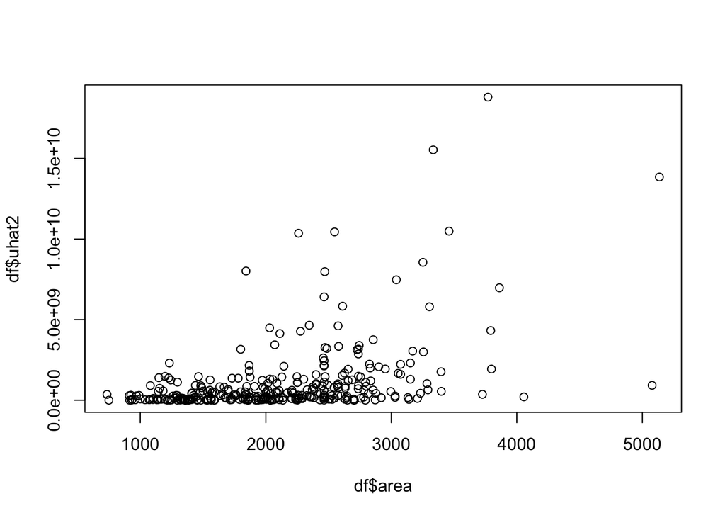

```r
#Eye-Ball Test
reg_eb <- lm(price ~ area, data=df)
df$uhat2 <- reg_eb$residuals^2
plot(df$area, df$uhat2)
```

Based on the error variance there appears to be heteroskedasticity.

```r
#Breusch-Pagan Test
library(lmtest)
bptest(price ~ log(dist) + log(area) + rooms + baths + age, data=df)
```

```
##
##  studentized Breusch-Pagan test
##
## data:  price ~ log(dist) + log(area) + rooms + baths + age
## BP = 31.623, df = 5, p-value = 7.056e-06
```

With a LM test stat of 31.62 and a small p-value (7.056e-06) we can reject the null and conclude heteroskedasticity.

```r
bptest(log(price) ~ log(dist) + log(area) + rooms + baths + age, data=df)
```

```
##
##  studentized Breusch-Pagan test
##
## data:  log(price) ~ log(dist) + log(area) + rooms + baths + age
## BP = 9.3886, df = 5, p-value = 0.09453
```

**Other Issues**

There is likely other issues with the model that our regression does not account for. Omitted variables may be adding to the heteroskedasticity we see since the error term is absorbing these variables we are not including in the model. Some examples could be distance from the nearest shopping center, density of neighborhoods, or relation to nearest schools, to name a few. These could be impacting price more than is captured by our current model. Another potential problem with our model could be multicollinearity, though we tried to account for this with a joint significance test of two like variables (rooms and bathrooms). Multicollinearity occurs when two or more variables affect the dependent variable in the same way. There may be some collinearity between distance and area if there are larger houses built away from the incinerator plant as can expected in affluent neighborhoods.

**Conclusions**

A potential interpretation of these finding as they relate back to my original research topic idea on desalination plants could be recommendation for policy makers. The results of the regression show a positive affect of distance away from processing plants (an incineration plant in the case of the data) on the price of houses. In order to address this potential issue it would be advantageous to consider installation of these facilities further away from populations as to not affect their house prices. We know there are countless cases of governments placing facilities that are less desirable in areas where people have less resources to push against policies that may harm them. In the case of an incinerator possibly negatively affecting air quality or a desalination plant affecting the ecosystem of the surrounding area, these facilities should be implemented with those marginalized individuals in mind. As evident in the regression, larger plot sizes increase price, so it may be equitable for policy makers to consider placing these facilities near individuals with more relative land than those with less.